# Test a Perceptual Phenomenon

In psychology, the Stroop effect is a demonstration of interference in the reaction time of a task.

When the name of a color (e.g., "blue", "green", or "red") is printed in a color which is not denoted by the name (i.e., the word "red" printed in blue ink instead of red ink), naming the color of the word takes longer and is more prone to errors than when the color of the ink matches the name of the color.

#### 1. What is our independent variable? What is our dependent variable?

Independent variable is: The word/colour congruency is the varable being manipulated in the experiment

Dependent variable is: The time it takes to recognize/name the ink colors of the mismatch word/colour congruency

#### 2. What is an appropriate set of hypotheses for this task? What kind of statistical test do you expect to perform? Justify your choices.

Null Hypothsis, H0 - No Difference in time between two reading tasks (congruent or incongruent)

Alternate Hypothesis, H1 - incongruent task take more time than congruent. (naming the color of the word takes longer )

H0: μi ≤ μc (μi - population mean of incongruent values, μc - population mean of congruent values)

H1: μi > μc (μi - population mean of incongruent values, μc - population mean of congruent values)

- We have to compare the means of two related groups to determine the statistically significant difference between two means.
- We are assuming distributions are nearly normal and we are comparing 2 dependent samples of data
- our sample size less than 30 and we don't know the population standard deviations

#### 3. Report some descriptive statistics regarding this dataset. Include at least one measure of central tendency and at least one measure of variability.

```python
%matplotlib inline
import math
import matplotlib.pyplot as plt
import pandas as pd
import numpy as np
import seaborn as sns
from scipy import stats
import statsmodels.api as sm

stroopData = pd.read_csv("stroopdata.csv")
#print(stroopData)
stroopData.describe()
```

|  | Congruent | Incongruent |
| --- | --- | --- |
| count | 24.000000 | 24.000000 |
| mean | 14.051125 | 22.015917 |
| std | 3.559358 | 4.797057 |
| min | 8.630000 | 15.687000 |
| 25% | 11.895250 | 18.716750 |
| 50% | 14.356500 | 21.017500 |
| 75% | 16.200750 | 24.051500 |
| max | 22.328000 | 35.255000 |

```python
congruentData = stroopData["Congruent"]
print("Median for congruent Data ",congruentData.median())
```

```
Median for congruent Data  14.3565
```

```python
incongruentData = stroopData["Incongruent"]
print("Median for incongruent Data ",incongruentData.median())
```

```
Median for incongruent Data  21.0175
```

```python
print("Mean for congruent Data ",congruentData.mean())
```

```
Mean for congruent Data  14.051124999999999
```

```python
print("Mean for incongruent Data ",incongruentData.mean())
```

```
Mean for incongruent Data  22.015916666666666
```

```python
#Corrected the standard Deviation method
stroopData.std()
```

```
Congruent      3.559358
Incongruent    4.797057
dtype: float64
```

#### 4. Provide one or two visualizations that show the distribution of the sample data. Write one or two sentences noting what you observe about the plot or plots.

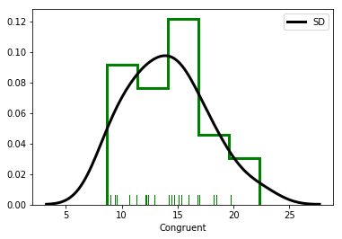

```python
#sns.distplot(congruentData)
sns.distplot(congruentData, rug=True, rug_kws={"color": "g"},kde_kws={"color": "k", "lw": 3, "label": "SD"},hist_kws={"histtype": "step", "linewidth": 3, "alpha": 1, "color": "g"})
```

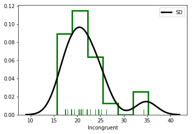

```python
sns.distplot(incongruentData, rug=True, rug_kws={"color": "g"},kde_kws={"color": "k", "lw": 3, "label": "SD"},hist_kws={"histtype": "step", "linewidth": 3, "alpha": 1, "color": "g"})
```

The histogram plots, although both graphs visually appear somewhat positively skewed,  
the mean is pretty close to the peak in both graphs which would indicate a normal distribution

#### 5. Now, perform the statistical test and report your results. What is your confidence level and your critical statistic value? Do you reject the null hypothesis or fail to reject it? Come to a conclusion in terms of the experiment task. Did the results match up with your expectations?

```python
test = stats.ttest_rel(congruentData, incongruentData)
print(test)
```

```
Ttest_relResult(statistic=-8.020706944109957, pvalue=4.103000585711178e-08)
```

Our t-statistic value is -8.020706944109957, and along with our degrees of freedom (23) this can be used to calculate a p-value.

The p-value is <0.001, which again isp-value<0.001 below than the standard thresholds of 0.05 or 0.01, so we reject the null hypothesis and we can say there is a statistically significant it takes less time to recognize the colour of words with the congruent condition compared to words with the incongruent condition.

Source :

```
https://en.wikipedia.org/wiki/Stroop_effect
http://puwenning.github.io/2016/01/11/P1-project-test-a-perceptual-phenomenon/
```